# ML Pipeline Preparation

Follow the instructions below to help you create your ML pipeline.

### 1. Import libraries and load data from database.

- Import Python libraries
- Load dataset from database with [`read_sql_table`](https://pandas.pydata.org/pandas-docs/stable/generated/pandas.read_sql_table.html)
- Define feature and target variables X and Y

```python
# import libraries
import numpy as np
import pandas as pd
from sqlalchemy import create_engine

import nltk

from nltk.tokenize import word_tokenize
from nltk.corpus import stopwords
from nltk.stem import WordNetLemmatizer

import re

from sklearn.pipeline import Pipeline
from sklearn.multioutput import MultiOutputClassifier
from sklearn.ensemble import RandomForestClassifier
from sklearn.naive_bayes import MultinomialNB
from sklearn.feature_extraction.text import CountVectorizer, TfidfTransformer
from sklearn.model_selection import train_test_split, GridSearchCV

from sklearn.metrics import accuracy_score, precision_score, recall_score,f1_score, make_scorer, roc_curve
import pickle

import matplotlib.pyplot as plt
import seaborn as sns
```

```python
nltk.download('punkt')
nltk.download('stopwords')
nltk.download('wordnet')
```

```
True
```

```python
# load data from database
engine = create_engine('sqlite:///InsertDatabaseName.db')
df = pd.read_sql_table('InsertTableName',engine)
X = df['message']
Y = df.iloc[:,4:]
```

### 2. Write a tokenization function to process your text data

```python
def tokenize(text):
    """
        Process the text and Lemmatize it

        Parameters
        ----------
        text(str)

        Returns
        -------
        lem(list): Lemmatized text

    """

    text = re.sub(r"[^a-zA-Z0-9]", " ", text.lower()) #Text to lower and remove punct

    text = word_tokenize(text)

    text = [w for w in text if w not in stopwords.words("english")] #remove stopwords

    lem = [WordNetLemmatizer().lemmatize(w,pos='v') for w in text] # Lemmatize with v pos tag

    return lem
```

### 3. Build a machine learning pipeline

```python
#Create Pipeline
#RandomForests class_weight is balanced because there is imbalanced data set so that we need to balance the weight
#Other parameter sets with heuristic approach according to know-how
pipeline = Pipeline([
    ('vectorizer', CountVectorizer(tokenizer = tokenize)),
    ('tfidf', TfidfTransformer()),
    ('clf', MultiOutputClassifier(RandomForestClassifier(n_estimators = 100,class_weight='balanced',max_depth = 20, min_samples_split = 2,n_jobs=-1)))
])
```

### 4. Train pipeline

- Split data into train and test sets
- Train pipeline

```python
#Train Pipeline
X_train, X_test, y_train,y_test = train_test_split(X,Y,test_size = 0.3,random_state = 42)

pipeline.fit(X_train,y_train)
```

```
Pipeline(memory=None,
     steps=[('vectorizer', CountVectorizer(analyzer='word', binary=False, decode_error='strict',
        dtype=<class 'numpy.int64'>, encoding='utf-8', input='content',
        lowercase=True, max_df=1.0, max_features=None, min_df=1,
        ngram_range=(1, 1), preprocessor=None, stop_words=None,
       ..._score=False,
            random_state=None, verbose=0, warm_start=False),
           n_jobs=None))])
```

### 5. Test your model

Report the f1 score, precision and recall for each output category of the dataset. You can do this by iterating through the columns and calling sklearn's `classification_report` on each.

```python
def scores(y_test,y_pred):


    '''
      Calculate the Accuracy, Precision, Recall and F1 Score and Return Scores for all Targets

        Parameters
        ----------
        y_test: Actual Data
        y_pred: Predicted Data

        Returns
        -------
        df_score: Scores which includes Acc, Prec, Recall, F1 Score and True Rate for all Targets

    '''


    scorelist = []

    #Iterate over y columns
    for i,target in enumerate(y_test):
        #Calculate metrics for actual and predicted data
        accuracy = accuracy_score(y_test[target],y_pred[:,i])
        precision = precision_score(y_test[target],y_pred[:,i])
        recall = recall_score(y_test[target],y_pred[:,i])
        f1 = f1_score(y_test[target],y_pred[:,i])
        scorelist.append([accuracy,precision,recall,f1,round(y_test[target].mean()*100,2)])


    #Create df which includes all metrics for all y columns
    df_score = pd.DataFrame(data = np.array(scorelist), index = y_test.columns, columns=['Acc','Pre','Rec','F1','True Rate (%)'])



    return df_score
```

```python
pred = pipeline.predict(X_test) #Get Test Set Prediction Using Pipeline
pred_train = pipeline.predict(X_train) #Get Train Set Prediction Using Pipeline

first_scores_train = scores(y_train,pred_train) #Training Set Scores
first_scores = scores(y_test,pred)# Test Set Scıres
```

Some of attributes are unbalanced so that accuracy is high but precision and recall 0 or close to 0

```python
def column_index(df, query_cols):
    """
        Get the column indexes for df[query_cols] columns

        Parameters
        ----------
        df: Dataset
        query_cols: list of column names

        Returns
        -------
        sidx[np.searchsorted(cols,query_cols,sorter=sidx)]: Get the column indexes

    """

    cols = df.columns.values
    sidx = np.argsort(cols)
    return sidx[np.searchsorted(cols,query_cols,sorter=sidx)]
```

```python
imbalanced_cols = first_scores[first_scores['True Rate (%)'] < 10].index.values #Get the Imbalanced Columns
imbalanced_col_index = column_index(y_test, imbalanced_cols) #Get the indexes of imbalanced Columns
```

```python
def multiple_roc(model,X,y,y_indexes):

    """
        Create Roc Curve Plot for Multiple Outputs

        Parameters
        ----------
        model: Estimator for predict Outputs
        X: Independent Variables
        y: Dependent Variables
        y_indexes: Indexes of Selected Dependent Variables

        Returns
        -------
        None

    """

    y_pred = model.predict_proba(X) #Predict probabilities
    y_cols = y.columns # Get Columns

    fpr = []
    tpr = []

    #calculate fpr and tpr for every y columns
    for i in range(len(y_test_cols)):
        fpr_col, tpr_col, thresh = roc_curve(y.iloc[:,i], y_pred[i][:,1])
        fpr.append(fpr_col)
        tpr.append(tpr_col)
        threshold.append(thresh)

    #Create Roc Curve Plot
    plt.figure(figsize = (20,10))

    for i in y_indexes:
        plt.plot([0, 1], [0, 1], '--k')
        plt.plot(fpr[i], tpr[i], label=y_cols[i])
        plt.xlabel('False positive rate')
        plt.ylabel('True positive rate')
        plt.title('ROC curve')
        plt.legend(loc='best')
        plt.text(np.mean(fpr[i]),np.mean(tpr[i]),str(y_cols[i]))

    plt.show()
```

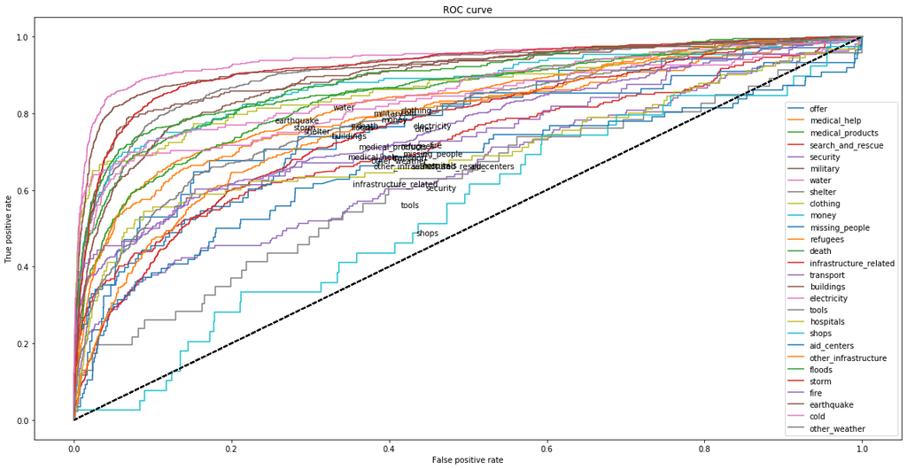

```python
multiple_roc(pipeline,X_test,y_test,imbalanced_col_index)
```

We can see that shops did not learn from the model very well because it is around the diagonal line. The other variables learned from the model better.

```python
first_scores.loc['shops',:]
```

```
Acc              0.995006
Pre              0.000000
Rec              0.000000
F1               0.000000
True Rate (%)    0.500000
Name: shops, dtype: float64
```

Shops True Rate is %0.5 so that it is highly imbalanced

### 6. Improve your model

Use grid search to find better parameters.

```python
pipeline.get_params()
```

```
{'memory': None,
 'steps': [('vectorizer',
   CountVectorizer(analyzer='word', binary=False, decode_error='strict',
           dtype=<class 'numpy.int64'>, encoding='utf-8', input='content',
           lowercase=True, max_df=1.0, max_features=None, min_df=1,
           ngram_range=(1, 1), preprocessor=None, stop_words=None,
           strip_accents=None, token_pattern='(?u)\\b\\w\\w+\\b',
           tokenizer=<function tokenize at 0x0000018B9CDB9DC8>,
           vocabulary=None)),
  ('tfidf',
   TfidfTransformer(norm='l2', smooth_idf=True, sublinear_tf=False, use_idf=True)),
  ('clf',
   MultiOutputClassifier(estimator=RandomForestClassifier(bootstrap=True, class_weight='balanced',
               criterion='gini', max_depth=20, max_features='auto',
               max_leaf_nodes=None, min_impurity_decrease=0.0,
               min_impurity_split=None, min_samples_leaf=1,
               min_samples_split=2, min_weight_fraction_leaf=0.0,
               n_estimators=100, n_jobs=-1, oob_score=False,
               random_state=None, verbose=0, warm_start=False),
              n_jobs=None))],
 'vectorizer': CountVectorizer(analyzer='word', binary=False, decode_error='strict',
         dtype=<class 'numpy.int64'>, encoding='utf-8', input='content',
         lowercase=True, max_df=1.0, max_features=None, min_df=1,
         ngram_range=(1, 1), preprocessor=None, stop_words=None,
         strip_accents=None, token_pattern='(?u)\\b\\w\\w+\\b',
         tokenizer=<function tokenize at 0x0000018B9CDB9DC8>,
         vocabulary=None),
 'tfidf': TfidfTransformer(norm='l2', smooth_idf=True, sublinear_tf=False, use_idf=True),
 'clf': MultiOutputClassifier(estimator=RandomForestClassifier(bootstrap=True, class_weight='balanced',
             criterion='gini', max_depth=20, max_features='auto',
             max_leaf_nodes=None, min_impurity_decrease=0.0,
             min_impurity_split=None, min_samples_leaf=1,
             min_samples_split=2, min_weight_fraction_leaf=0.0,
             n_estimators=100, n_jobs=-1, oob_score=False,
             random_state=None, verbose=0, warm_start=False),
            n_jobs=None),
 'vectorizer__analyzer': 'word',
 'vectorizer__binary': False,
 'vectorizer__decode_error': 'strict',
 'vectorizer__dtype': numpy.int64,
```

[output cut: 27 more lines]

```
 'clf__estimator__min_weight_fraction_leaf': 0.0,
 'clf__estimator__n_estimators': 100,
 'clf__estimator__n_jobs': -1,
 'clf__estimator__oob_score': False,
 'clf__estimator__random_state': None,
 'clf__estimator__verbose': 0,
 'clf__estimator__warm_start': False,
 'clf__estimator': RandomForestClassifier(bootstrap=True, class_weight='balanced',
             criterion='gini', max_depth=20, max_features='auto',
             max_leaf_nodes=None, min_impurity_decrease=0.0,
             min_impurity_split=None, min_samples_leaf=1,
             min_samples_split=2, min_weight_fraction_leaf=0.0,
             n_estimators=100, n_jobs=-1, oob_score=False,
             random_state=None, verbose=0, warm_start=False),
 'clf__n_jobs': None}
```

```python
def performance_metric(y_true, y_pred):
    """Calculate average recall score for all targets

    Args:
    y_true: array. Array containing actual labels.
    y_pred: array. Array containing predicted labels.

    Returns:
    score: float. Median recall score
    """
    f1_list = []
    for i in range(np.shape(y_pred)[1]):
        f1 = f1_score(np.array(y_true)[:, i], y_pred[:, i])
        f1_list.append(f1)

    score = np.median(f1_list)
    return score
```

```python
#Create Dictionary for tuning min_samples_split and n_estimators in Random Forest Classifier
parameters = {
    'clf__estimator__min_samples_split':[2,5,10],
    'clf__estimator__n_estimators' :[50,100,200]
}

scorer = make_scorer(performance_metric)

cv = GridSearchCV(pipeline,param_grid=parameters,verbose=5,n_jobs = 5,scoring=scorer)
```

### 7. Test your model

Show the accuracy, precision, and recall of the tuned model.

Since this project focuses on code quality, process, and pipelines, there is no minimum performance metric needed to pass. However, make sure to fine tune your models for accuracy, precision and recall to make your project stand out - especially for your portfolio!

```python
cv.fit(X_train,y_train) #Fit again for finding the best parameters
```

```
Fitting 3 folds for each of 9 candidates, totalling 27 fits
```

```
[Parallel(n_jobs=5)]: Done   8 tasks      | elapsed: 15.2min
[Parallel(n_jobs=5)]: Done  24 out of  27 | elapsed: 37.5min remaining:  4.7min
[Parallel(n_jobs=5)]: Done  27 out of  27 | elapsed: 43.7min finished
```

```
GridSearchCV(cv='warn', error_score='raise-deprecating',
       estimator=Pipeline(memory=None,
     steps=[('vectorizer', CountVectorizer(analyzer='word', binary=False, decode_error='strict',
        dtype=<class 'numpy.int64'>, encoding='utf-8', input='content',
        lowercase=True, max_df=1.0, max_features=None, min_df=1,
        ngram_range=(1, 1), preprocessor=None, stop_words=None,
       ..._score=False,
            random_state=None, verbose=0, warm_start=False),
           n_jobs=None))]),
       fit_params=None, iid='warn', n_jobs=5,
       param_grid={'clf__estimator__min_samples_split': [2, 5, 10], 'clf__estimator__n_estimators': [50, 100, 200]},
       pre_dispatch='2*n_jobs', refit=True, return_train_score='warn',
       scoring=make_scorer(performance_metric), verbose=5)
```

```python
cv.best_params_
```

```
{'clf__estimator__min_samples_split': 10, 'clf__estimator__n_estimators': 100}
```

```python
y_pred = cv.predict(X_test) #Predict test set using best models from CrossValidation
```

```python
tuned_score = scores(y_test,y_pred) #Get tuned Scores
```

```python
#Merge tuned scores and first models scores
merged_results = pd.merge(tuned_score,first_scores,left_index=True,right_index=True,suffixes=('_tuned','_first'))
```

```python
merged_results
```

|  | Acc_tuned | Pre_tuned | Rec_tuned | F1_tuned | True Rate (%)_tuned | Acc_first | Pre_first | Rec_first | F1_first | True Rate (%)_first |
| --- | --- | --- | --- | --- | --- | --- | --- | --- | --- | --- |
| related | 0.756051 | 0.918152 | 0.745834 | 0.823070 | 76.08 | 0.750800 | 0.912281 | 0.743982 | 0.819581 | 76.08 |
| request | 0.868613 | 0.593087 | 0.733683 | 0.655936 | 17.07 | 0.872199 | 0.603204 | 0.734434 | 0.662382 | 17.07 |
| offer | 0.995646 | 0.000000 | 0.000000 | 0.000000 | 0.44 | 0.995646 | 0.000000 | 0.000000 | 0.000000 | 0.44 |
| aid_related | 0.766039 | 0.741957 | 0.680767 | 0.710046 | 42.08 | 0.768600 | 0.742539 | 0.688984 | 0.714759 | 42.08 |
| medical_help | 0.909720 | 0.456738 | 0.500000 | 0.477391 | 8.25 | 0.916250 | 0.491987 | 0.476708 | 0.484227 | 8.25 |
| medical_products | 0.930209 | 0.381555 | 0.509662 | 0.436401 | 5.30 | 0.934179 | 0.400794 | 0.487923 | 0.440087 | 5.30 |
| search_and_rescue | 0.965937 | 0.396947 | 0.217573 | 0.281081 | 3.06 | 0.969010 | 0.484848 | 0.200837 | 0.284024 | 3.06 |
| security | 0.974004 | 0.178082 | 0.083333 | 0.113537 | 2.00 | 0.977718 | 0.275000 | 0.070513 | 0.112245 | 2.00 |
| military | 0.960943 | 0.445087 | 0.576779 | 0.502447 | 3.42 | 0.965168 | 0.490975 | 0.509363 | 0.500000 | 3.42 |
| water | 0.951722 | 0.591588 | 0.851562 | 0.698159 | 6.56 | 0.953643 | 0.609649 | 0.814453 | 0.697324 | 6.56 |
| food | 0.926111 | 0.642654 | 0.772210 | 0.701500 | 11.24 | 0.916635 | 0.602160 | 0.761959 | 0.672700 | 11.24 |
| shelter | 0.926495 | 0.581019 | 0.703081 | 0.636248 | 9.14 | 0.921757 | 0.561974 | 0.654062 | 0.604531 | 9.14 |
| clothing | 0.984761 | 0.517241 | 0.487805 | 0.502092 | 1.58 | 0.986938 | 0.620690 | 0.439024 | 0.514286 | 1.58 |
| money | 0.976694 | 0.537879 | 0.369792 | 0.438272 | 2.46 | 0.977462 | 0.571429 | 0.333333 | 0.421053 | 2.46 |
| missing_people | 0.988987 | 0.562500 | 0.102273 | 0.173077 | 1.13 | 0.988731 | 0.500000 | 0.090909 | 0.153846 | 1.13 |
| refugees | 0.961327 | 0.412245 | 0.389961 | 0.400794 | 3.32 | 0.962863 | 0.427230 | 0.351351 | 0.385593 | 3.32 |
| death | 0.961711 | 0.601744 | 0.560976 | 0.580645 | 4.73 | 0.956845 | 0.549383 | 0.482385 | 0.513709 | 4.73 |
| other_aid | 0.828531 | 0.371774 | 0.451518 | 0.407784 | 13.07 | 0.823025 | 0.353371 | 0.426053 | 0.386323 | 13.07 |
| infrastructure_related | 0.887053 | 0.267696 | 0.399232 | 0.320493 | 6.67 | 0.898835 | 0.270869 | 0.305182 | 0.287004 | 6.67 |
| transport | 0.940069 | 0.365482 | 0.397790 | 0.380952 | 4.64 | 0.953771 | 0.501887 | 0.367403 | 0.424242 | 4.64 |
| buildings | 0.947240 | 0.520000 | 0.544186 | 0.531818 | 5.51 | 0.947753 | 0.530387 | 0.446512 | 0.484848 | 5.51 |
| electricity | 0.980535 | 0.482456 | 0.371622 | 0.419847 | 1.90 | 0.982328 | 0.558140 | 0.324324 | 0.410256 | 1.90 |
| tools | 0.994109 | 0.000000 | 0.000000 | 0.000000 | 0.59 | 0.994109 | 0.000000 | 0.000000 | 0.000000 | 0.59 |
| hospitals | 0.988091 | 0.333333 | 0.033333 | 0.060606 | 1.15 | 0.988347 | 0.400000 | 0.022222 | 0.042105 | 1.15 |
| shops | 0.995006 | 0.000000 | 0.000000 | 0.000000 | 0.50 | 0.995006 | 0.000000 | 0.000000 | 0.000000 | 0.50 |
| aid_centers | 0.988219 | 0.200000 | 0.023256 | 0.041667 | 1.10 | 0.988731 | 0.250000 | 0.011628 | 0.022222 | 1.10 |
| other_infrastructure | 0.920348 | 0.216667 | 0.297143 | 0.250602 | 4.48 | 0.925599 | 0.228235 | 0.277143 | 0.250323 | 4.48 |
| weather_related | 0.860930 | 0.762631 | 0.731261 | 0.746617 | 28.02 | 0.860033 | 0.765648 | 0.721207 | 0.742763 | 28.02 |
| floods | 0.924190 | 0.527485 | 0.705790 | 0.603748 | 8.18 | 0.929312 | 0.556420 | 0.671362 | 0.608511 | 8.18 |
| storm | 0.926623 | 0.597049 | 0.706989 | 0.647385 | 9.53 | 0.930849 | 0.621718 | 0.700269 | 0.658660 | 9.53 |
| fire | 0.989627 | 0.620690 | 0.204545 | 0.307692 | 1.13 | 0.988987 | 0.625000 | 0.056818 | 0.104167 | 1.13 |
| earthquake | 0.955820 | 0.798771 | 0.708447 | 0.750903 | 9.40 | 0.950826 | 0.777778 | 0.667575 | 0.718475 | 9.40 |
| cold | 0.981176 | 0.605769 | 0.372781 | 0.461538 | 2.16 | 0.982072 | 0.710145 | 0.289941 | 0.411765 | 2.16 |
| other_weather | 0.918556 | 0.260618 | 0.347938 | 0.298013 | 4.97 | 0.928672 | 0.317495 | 0.378866 | 0.345476 | 4.97 |
| direct_report | 0.816110 | 0.528801 | 0.658694 | 0.586644 | 19.81 | 0.816238 | 0.530011 | 0.639302 | 0.579549 | 19.81 |

Tuned Scores are slightly better than the first model

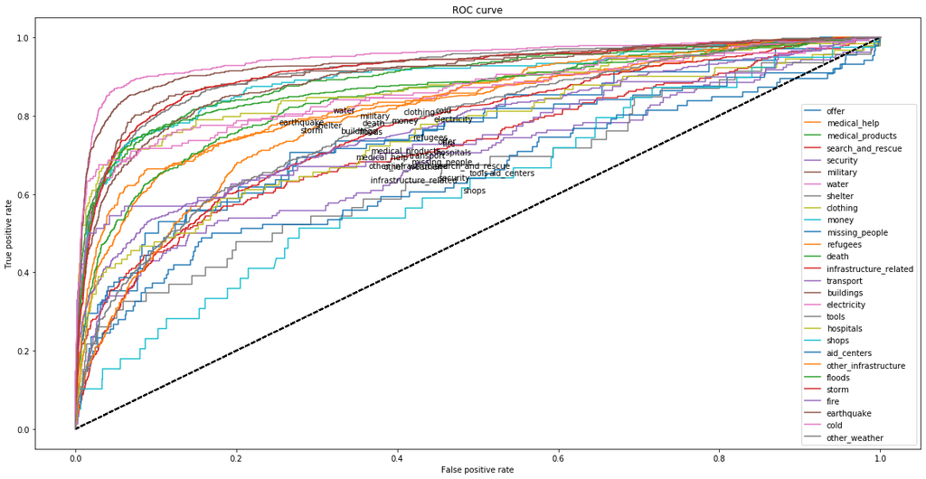

```python
multiple_roc(cv,X_test,y_test,imbalanced_col_index)
```

tuned models roc curve is better than the first model so it is learned better than the first model. Shops attribute is not around the diagonal line also.

```python
cv.best_params_
```

```
{'clf__estimator__min_samples_split': 10, 'clf__estimator__n_estimators': 100}
```

### 8. Try improving your model further. Here are a few ideas:

- try other machine learning algorithms
- add other features besides the TF-IDF

```python
pipeline2 = Pipeline([
    ('vectorizer', CountVectorizer(tokenizer = tokenize)),
    ('tfidf', TfidfTransformer()),
    ('clf', MultiOutputClassifier(MultinomialNB()))
])

pipeline2.fit(X_train,y_train) # Fit the train set to second pipeline

pred2 = pipeline2.predict(X_test) #Get predictions

scores(y_test,pred2) #Get Scores
```

|  | Acc | Pre | Rec | F1 | True Rate (%) |
| --- | --- | --- | --- | --- | --- |
| related | 0.777436 | 0.776331 | 0.993772 | 0.871696 | 76.08 |
| request | 0.860802 | 0.841667 | 0.227307 | 0.357944 | 17.07 |
| offer | 0.995646 | 0.000000 | 0.000000 | 0.000000 | 0.44 |
| aid_related | 0.754130 | 0.748003 | 0.626902 | 0.682119 | 42.08 |
| medical_help | 0.917275 | 0.000000 | 0.000000 | 0.000000 | 8.25 |
| medical_products | 0.947112 | 1.000000 | 0.002415 | 0.004819 | 5.30 |
| search_and_rescue | 0.969394 | 0.000000 | 0.000000 | 0.000000 | 3.06 |
| security | 0.980023 | 0.000000 | 0.000000 | 0.000000 | 2.00 |
| military | 0.965809 | 0.000000 | 0.000000 | 0.000000 | 3.42 |
| water | 0.934563 | 1.000000 | 0.001953 | 0.003899 | 6.56 |
| food | 0.888718 | 0.645161 | 0.022779 | 0.044004 | 11.24 |
| shelter | 0.908695 | 1.000000 | 0.001401 | 0.002797 | 9.14 |
| clothing | 0.984249 | 0.000000 | 0.000000 | 0.000000 | 1.58 |
| money | 0.975413 | 0.000000 | 0.000000 | 0.000000 | 2.46 |
| missing_people | 0.988731 | 0.000000 | 0.000000 | 0.000000 | 1.13 |
| refugees | 0.966833 | 0.000000 | 0.000000 | 0.000000 | 3.32 |
| death | 0.952747 | 0.000000 | 0.000000 | 0.000000 | 4.73 |
| other_aid | 0.869253 | 0.000000 | 0.000000 | 0.000000 | 13.07 |
| infrastructure_related | 0.933282 | 0.000000 | 0.000000 | 0.000000 | 6.67 |
| transport | 0.953643 | 0.000000 | 0.000000 | 0.000000 | 4.64 |
| buildings | 0.944935 | 0.000000 | 0.000000 | 0.000000 | 5.51 |
| electricity | 0.981048 | 0.000000 | 0.000000 | 0.000000 | 1.90 |
| tools | 0.994109 | 0.000000 | 0.000000 | 0.000000 | 0.59 |
| hospitals | 0.988475 | 0.000000 | 0.000000 | 0.000000 | 1.15 |
| shops | 0.995006 | 0.000000 | 0.000000 | 0.000000 | 0.50 |
| aid_centers | 0.988987 | 0.000000 | 0.000000 | 0.000000 | 1.10 |
| other_infrastructure | 0.955180 | 0.000000 | 0.000000 | 0.000000 | 4.48 |
| weather_related | 0.819311 | 0.854148 | 0.428245 | 0.570472 | 28.02 |
| floods | 0.918556 | 1.000000 | 0.004695 | 0.009346 | 8.18 |
| storm | 0.905109 | 0.615385 | 0.010753 | 0.021136 | 9.53 |
| fire | 0.988731 | 0.000000 | 0.000000 | 0.000000 | 1.13 |
| earthquake | 0.914970 | 0.916667 | 0.104905 | 0.188264 | 9.40 |
| cold | 0.978358 | 0.000000 | 0.000000 | 0.000000 | 2.16 |
| other_weather | 0.950314 | 0.000000 | 0.000000 | 0.000000 | 4.97 |
| direct_report | 0.827123 | 0.812698 | 0.165482 | 0.274973 | 19.81 |

Many of cases have 0 F1 Score so that i'm going to ignore Naive Bayes Approach and use the tuned RandomForestClassifier

### 9. Export your model as a pickle file

```python
pickle.dump(cv, open('disaster_ml_model.pkl', 'wb'))
```

### 10. Use this notebook to complete `train.py`

Use the template file attached in the Resources folder to write a script that runs the steps above to create a database and export a model based on a new dataset specified by the user.